# Risk Factor Analysis

## Outcome Variable

**Outcome Variable:** stunted

## Predictor Variables

**Intervention Variable:** safeh20

**Adjustment Set:**

unadjusted

## Stratifying Variables

The analysis was stratified on these variable(s):

- agecat
- studyid
- country

## Data Summary

| agecat | studyid | country | safeh20 | stunted | n_cell | n |
| --- | --- | --- | --- | --- | --- | --- |
| Birth | JiVitA-3 | BANGLADESH | 1 | 0 | 15028 | 22432 |
| Birth | JiVitA-3 | BANGLADESH | 1 | 1 | 7364 | 22432 |
| Birth | JiVitA-3 | BANGLADESH | 0 | 0 | 22 | 22432 |
| Birth | JiVitA-3 | BANGLADESH | 0 | 1 | 18 | 22432 |
| Birth | JiVitA-4 | BANGLADESH | 1 | 0 | 1964 | 2820 |
| Birth | JiVitA-4 | BANGLADESH | 1 | 1 | 856 | 2820 |
| Birth | JiVitA-4 | BANGLADESH | 0 | 0 | 0 | 2820 |
| Birth | JiVitA-4 | BANGLADESH | 0 | 1 | 0 | 2820 |
| Birth | MAL-ED | BANGLADESH | 1 | 0 | 0 | 213 |
| Birth | MAL-ED | BANGLADESH | 1 | 1 | 0 | 213 |
| Birth | MAL-ED | BANGLADESH | 0 | 0 | 176 | 213 |
| Birth | MAL-ED | BANGLADESH | 0 | 1 | 37 | 213 |
| Birth | MAL-ED | BRAZIL | 1 | 0 | 0 | 41 |
| Birth | MAL-ED | BRAZIL | 1 | 1 | 0 | 41 |
| Birth | MAL-ED | BRAZIL | 0 | 0 | 32 | 41 |
| Birth | MAL-ED | BRAZIL | 0 | 1 | 9 | 41 |
| Birth | MAL-ED | INDIA | 1 | 0 | 0 | 41 |
| Birth | MAL-ED | INDIA | 1 | 1 | 0 | 41 |
| Birth | MAL-ED | INDIA | 0 | 0 | 33 | 41 |
| Birth | MAL-ED | INDIA | 0 | 1 | 8 | 41 |
| Birth | MAL-ED | NEPAL | 1 | 0 | 1 | 26 |
| Birth | MAL-ED | NEPAL | 1 | 1 | 0 | 26 |
| Birth | MAL-ED | NEPAL | 0 | 0 | 23 | 26 |
| Birth | MAL-ED | NEPAL | 0 | 1 | 2 | 26 |
| Birth | MAL-ED | PERU | 1 | 0 | 8 | 207 |
| Birth | MAL-ED | PERU | 1 | 1 | 1 | 207 |
| Birth | MAL-ED | PERU | 0 | 0 | 176 | 207 |
| Birth | MAL-ED | PERU | 0 | 1 | 22 | 207 |
| Birth | MAL-ED | SOUTH AFRICA | 1 | 0 | 12 | 96 |
| Birth | MAL-ED | SOUTH AFRICA | 1 | 1 | 1 | 96 |

[output cut: 134 more lines]

The following strata were considered:

- agecat: 24 months, studyid: CONTENT, country: PERU
- agecat: 24 months, studyid: JiVitA-3, country: BANGLADESH
- agecat: 24 months, studyid: JiVitA-4, country: BANGLADESH
- agecat: 24 months, studyid: LCNI-5, country: MALAWI
- agecat: 24 months, studyid: MAL-ED, country: BANGLADESH
- agecat: 24 months, studyid: MAL-ED, country: BRAZIL
- agecat: 24 months, studyid: MAL-ED, country: INDIA
- agecat: 24 months, studyid: MAL-ED, country: NEPAL
- agecat: 24 months, studyid: MAL-ED, country: PERU
- agecat: 24 months, studyid: MAL-ED, country: SOUTH AFRICA
- agecat: 24 months, studyid: MAL-ED, country: TANZANIA, UNITED REPUBLIC OF
- agecat: 24 months, studyid: NIH-Birth, country: BANGLADESH
- agecat: 24 months, studyid: NIH-Crypto, country: BANGLADESH
- agecat: 24 months, studyid: PROVIDE, country: BANGLADESH
- agecat: 6 months, studyid: CONTENT, country: PERU
- agecat: 6 months, studyid: JiVitA-3, country: BANGLADESH
- agecat: 6 months, studyid: JiVitA-4, country: BANGLADESH
- agecat: 6 months, studyid: LCNI-5, country: MALAWI
- agecat: 6 months, studyid: MAL-ED, country: BANGLADESH
- agecat: 6 months, studyid: MAL-ED, country: BRAZIL
- agecat: 6 months, studyid: MAL-ED, country: INDIA
- agecat: 6 months, studyid: MAL-ED, country: NEPAL
- agecat: 6 months, studyid: MAL-ED, country: PERU
- agecat: 6 months, studyid: MAL-ED, country: SOUTH AFRICA
- agecat: 6 months, studyid: MAL-ED, country: TANZANIA, UNITED REPUBLIC OF
- agecat: 6 months, studyid: NIH-Birth, country: BANGLADESH
- agecat: 6 months, studyid: NIH-Crypto, country: BANGLADESH
- agecat: 6 months, studyid: PROVIDE, country: BANGLADESH
- agecat: 6 months, studyid: SAS-FoodSuppl, country: INDIA
- agecat: Birth, studyid: JiVitA-3, country: BANGLADESH
- agecat: Birth, studyid: JiVitA-4, country: BANGLADESH
- agecat: Birth, studyid: MAL-ED, country: BANGLADESH
- agecat: Birth, studyid: MAL-ED, country: BRAZIL
- agecat: Birth, studyid: MAL-ED, country: INDIA
- agecat: Birth, studyid: MAL-ED, country: NEPAL
- agecat: Birth, studyid: MAL-ED, country: PERU
- agecat: Birth, studyid: MAL-ED, country: SOUTH AFRICA
- agecat: Birth, studyid: MAL-ED, country: TANZANIA, UNITED REPUBLIC OF
- agecat: Birth, studyid: NIH-Birth, country: BANGLADESH
- agecat: Birth, studyid: NIH-Crypto, country: BANGLADESH
- agecat: Birth, studyid: PROVIDE, country: BANGLADESH

### Dropped Strata

Some strata were dropped due to rare outcomes:

- agecat: Birth, studyid: JiVitA-4, country: BANGLADESH
- agecat: Birth, studyid: MAL-ED, country: BANGLADESH
- agecat: Birth, studyid: MAL-ED, country: BRAZIL
- agecat: Birth, studyid: MAL-ED, country: INDIA
- agecat: Birth, studyid: MAL-ED, country: NEPAL
- agecat: Birth, studyid: MAL-ED, country: PERU
- agecat: Birth, studyid: MAL-ED, country: SOUTH AFRICA
- agecat: Birth, studyid: NIH-Birth, country: BANGLADESH
- agecat: Birth, studyid: NIH-Crypto, country: BANGLADESH
- agecat: Birth, studyid: PROVIDE, country: BANGLADESH
- agecat: 6 months, studyid: CONTENT, country: PERU
- agecat: 6 months, studyid: JiVitA-4, country: BANGLADESH
- agecat: 6 months, studyid: MAL-ED, country: BANGLADESH
- agecat: 6 months, studyid: MAL-ED, country: BRAZIL
- agecat: 6 months, studyid: MAL-ED, country: INDIA
- agecat: 6 months, studyid: MAL-ED, country: NEPAL
- agecat: 6 months, studyid: MAL-ED, country: PERU
- agecat: 6 months, studyid: NIH-Birth, country: BANGLADESH
- agecat: 6 months, studyid: NIH-Crypto, country: BANGLADESH
- agecat: 6 months, studyid: PROVIDE, country: BANGLADESH
- agecat: 6 months, studyid: SAS-FoodSuppl, country: INDIA
- agecat: 24 months, studyid: CONTENT, country: PERU
- agecat: 24 months, studyid: JiVitA-3, country: BANGLADESH
- agecat: 24 months, studyid: JiVitA-4, country: BANGLADESH
- agecat: 24 months, studyid: MAL-ED, country: BANGLADESH
- agecat: 24 months, studyid: MAL-ED, country: BRAZIL
- agecat: 24 months, studyid: MAL-ED, country: INDIA
- agecat: 24 months, studyid: MAL-ED, country: NEPAL
- agecat: 24 months, studyid: MAL-ED, country: PERU
- agecat: 24 months, studyid: NIH-Birth, country: BANGLADESH
- agecat: 24 months, studyid: NIH-Crypto, country: BANGLADESH
- agecat: 24 months, studyid: PROVIDE, country: BANGLADESH

## Methods Detail

We’re interested in the causal parameters $E[Y_a]$ for all values of $a \in \mathcal{A}$. These parameters represent the mean outcome if, possibly contrary to fact, we intervened to set all units to have $A=a$. Under the randomization and positivity assumptions, these are identified by the statistical parameters $\psi_a=E_W[E_{Y|A,W}(Y|A=a,W)]$. In addition, we’re interested in the mean of $Y$, $E[Y]$ under no intervention (the observed mean). We will estimate these parameters by using SuperLearner to fit the relevant likelihood factors – $E_{Y|A,W}(Y|A=a,W)$ and $p(A=a|W)$, and then updating our likelihood fit using a joint TMLE.

For unadjusted analyses ($W=\{\}$), initial likelihoods were estimated using Lrnr_glm to estimate the simple $E(Y|A)$ and Lrnr_mean to estimate $p(A)$. For adjusted analyses, a small library containing Lrnr_glmnet, Lrnr_xgboost, and Lrnr_mean was used.

Having estimated these parameters, we will then use the delta method to estimate relative risks and attributable risks relative to a prespecified baseline level of $A$.

# Results Detail

## Results Plots

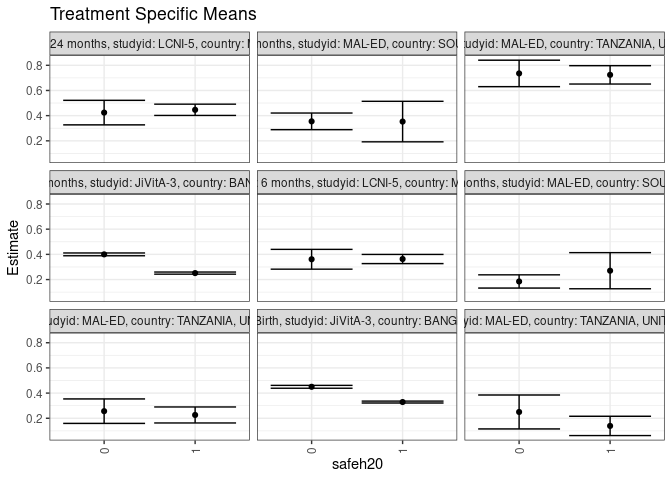

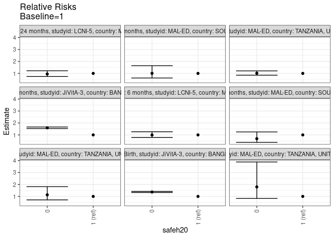

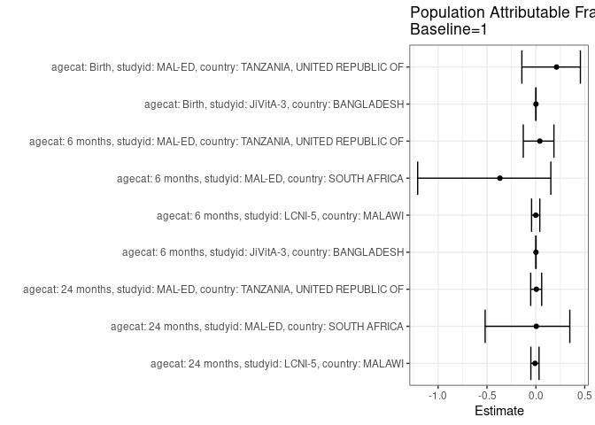

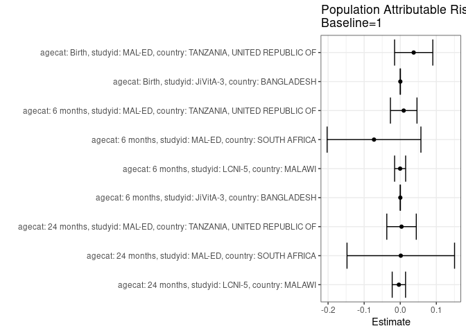

## Results Table

### Parameter: TSM

| agecat | studyid | country | intervention_level | baseline_level | estimate | ci_lower | ci_upper |
| --- | --- | --- | --- | --- | --- | --- | --- |
| Birth | JiVitA-3 | BANGLADESH | 1 | NA | 0.3288675 | 0.3213251 | 0.3364098 |
| Birth | JiVitA-3 | BANGLADESH | 0 | NA | 0.4500000 | 0.4385953 | 0.4614047 |
| Birth | MAL-ED | TANZANIA, UNITED REPUBLIC OF | 1 | NA | 0.1392405 | 0.0625766 | 0.2159044 |
| Birth | MAL-ED | TANZANIA, UNITED REPUBLIC OF | 0 | NA | 0.2500000 | 0.1152430 | 0.3847570 |
| 6 months | JiVitA-3 | BANGLADESH | 1 | NA | 0.2512066 | 0.2428938 | 0.2595194 |
| 6 months | JiVitA-3 | BANGLADESH | 0 | NA | 0.4000000 | 0.3887912 | 0.4112088 |
| 6 months | LCNI-5 | MALAWI | 1 | NA | 0.3630952 | 0.3267140 | 0.3994765 |
| 6 months | LCNI-5 | MALAWI | 0 | NA | 0.3611111 | 0.2826117 | 0.4396105 |
| 6 months | MAL-ED | SOUTH AFRICA | 1 | NA | 0.2702703 | 0.1268849 | 0.4136556 |
| 6 months | MAL-ED | SOUTH AFRICA | 0 | NA | 0.1848341 | 0.1323536 | 0.2373147 |
| 6 months | MAL-ED | TANZANIA, UNITED REPUBLIC OF | 1 | NA | 0.2261905 | 0.1627988 | 0.2895821 |
| 6 months | MAL-ED | TANZANIA, UNITED REPUBLIC OF | 0 | NA | 0.2564103 | 0.1593102 | 0.3535104 |
| 24 months | LCNI-5 | MALAWI | 1 | NA | 0.4463158 | 0.4015721 | 0.4910595 |
| 24 months | LCNI-5 | MALAWI | 0 | NA | 0.4242424 | 0.3268027 | 0.5216821 |
| 24 months | MAL-ED | SOUTH AFRICA | 1 | NA | 0.3529412 | 0.1919694 | 0.5139130 |
| 24 months | MAL-ED | SOUTH AFRICA | 0 | NA | 0.3546798 | 0.2887284 | 0.4206312 |
| 24 months | MAL-ED | TANZANIA, UNITED REPUBLIC OF | 1 | NA | 0.7241379 | 0.6512186 | 0.7970573 |
| 24 months | MAL-ED | TANZANIA, UNITED REPUBLIC OF | 0 | NA | 0.7352941 | 0.6301880 | 0.8404002 |

### Parameter: E(Y)

| agecat | studyid | country | intervention_level | baseline_level | estimate | ci_lower | ci_upper |
| --- | --- | --- | --- | --- | --- | --- | --- |
| Birth | JiVitA-3 | BANGLADESH | NA | NA | 0.3290835 | 0.3217078 | 0.3364591 |
| Birth | MAL-ED | TANZANIA, UNITED REPUBLIC OF | NA | NA | 0.1764706 | 0.1076873 | 0.2452539 |
| 6 months | JiVitA-3 | BANGLADESH | NA | NA | 0.2513837 | 0.2432545 | 0.2595129 |
| 6 months | LCNI-5 | MALAWI | NA | NA | 0.3627451 | 0.3297365 | 0.3957537 |
| 6 months | MAL-ED | SOUTH AFRICA | NA | NA | 0.1975806 | 0.1479246 | 0.2472367 |
| 6 months | MAL-ED | TANZANIA, UNITED REPUBLIC OF | NA | NA | 0.2357724 | 0.1826200 | 0.2889248 |
| 24 months | LCNI-5 | MALAWI | NA | NA | 0.4425087 | 0.4018409 | 0.4831765 |
| 24 months | MAL-ED | SOUTH AFRICA | NA | NA | 0.3544304 | 0.2934024 | 0.4154584 |
| 24 months | MAL-ED | TANZANIA, UNITED REPUBLIC OF | NA | NA | 0.7276995 | 0.6677783 | 0.7876207 |

### Parameter: RR

| agecat | studyid | country | intervention_level | baseline_level | estimate | ci_lower | ci_upper |
| --- | --- | --- | --- | --- | --- | --- | --- |
| Birth | JiVitA-3 | BANGLADESH | 1 | 1 | 1.0000000 | 1.0000000 | 1.000000 |
| Birth | JiVitA-3 | BANGLADESH | 0 | 1 | 1.3683324 | 1.3233952 | 1.414796 |
| Birth | MAL-ED | TANZANIA, UNITED REPUBLIC OF | 1 | 1 | 1.0000000 | 1.0000000 | 1.000000 |
| Birth | MAL-ED | TANZANIA, UNITED REPUBLIC OF | 0 | 1 | 1.7954545 | 0.8308895 | 3.879766 |
| 6 months | JiVitA-3 | BANGLADESH | 1 | 1 | 1.0000000 | 1.0000000 | 1.000000 |
| 6 months | JiVitA-3 | BANGLADESH | 0 | 1 | 1.5923150 | 1.5266883 | 1.660763 |
| 6 months | LCNI-5 | MALAWI | 1 | 1 | 1.0000000 | 1.0000000 | 1.000000 |
| 6 months | LCNI-5 | MALAWI | 0 | 1 | 0.9945355 | 0.7828275 | 1.263498 |
| 6 months | MAL-ED | SOUTH AFRICA | 1 | 1 | 1.0000000 | 1.0000000 | 1.000000 |
| 6 months | MAL-ED | SOUTH AFRICA | 0 | 1 | 0.6838863 | 0.3746770 | 1.248276 |
| 6 months | MAL-ED | TANZANIA, UNITED REPUBLIC OF | 1 | 1 | 1.0000000 | 1.0000000 | 1.000000 |
| 6 months | MAL-ED | TANZANIA, UNITED REPUBLIC OF | 0 | 1 | 1.1336032 | 0.7077139 | 1.815785 |
| 24 months | LCNI-5 | MALAWI | 1 | 1 | 1.0000000 | 1.0000000 | 1.000000 |
| 24 months | LCNI-5 | MALAWI | 0 | 1 | 0.9505432 | 0.7398360 | 1.221260 |
| 24 months | MAL-ED | SOUTH AFRICA | 1 | 1 | 1.0000000 | 1.0000000 | 1.000000 |
| 24 months | MAL-ED | SOUTH AFRICA | 0 | 1 | 1.0049261 | 0.6140853 | 1.644522 |
| 24 months | MAL-ED | TANZANIA, UNITED REPUBLIC OF | 1 | 1 | 1.0000000 | 1.0000000 | 1.000000 |
| 24 months | MAL-ED | TANZANIA, UNITED REPUBLIC OF | 0 | 1 | 1.0154062 | 0.8525161 | 1.209420 |

### Parameter: PAR

| agecat | studyid | country | intervention_level | baseline_level | estimate | ci_lower | ci_upper |
| --- | --- | --- | --- | --- | --- | --- | --- |
| Birth | JiVitA-3 | BANGLADESH | 1 | NA | 0.0002160 | -0.0001229 | 0.0005549 |
| Birth | MAL-ED | TANZANIA, UNITED REPUBLIC OF | 1 | NA | 0.0372301 | -0.0157317 | 0.0901918 |
| 6 months | JiVitA-3 | BANGLADESH | 1 | NA | 0.0001771 | -0.0001696 | 0.0005239 |
| 6 months | LCNI-5 | MALAWI | 1 | NA | -0.0003501 | -0.0156185 | 0.0149182 |
| 6 months | MAL-ED | SOUTH AFRICA | 1 | NA | -0.0726896 | -0.2026528 | 0.0572736 |
| 6 months | MAL-ED | TANZANIA, UNITED REPUBLIC OF | 1 | NA | 0.0095819 | -0.0272284 | 0.0463921 |
| 24 months | LCNI-5 | MALAWI | 1 | NA | -0.0038071 | -0.0223126 | 0.0146985 |
| 24 months | MAL-ED | SOUTH AFRICA | 1 | NA | 0.0014892 | -0.1475131 | 0.1504915 |
| 24 months | MAL-ED | TANZANIA, UNITED REPUBLIC OF | 1 | NA | 0.0035616 | -0.0372839 | 0.0444071 |

### Parameter: PAF

| agecat | studyid | country | intervention_level | baseline_level | estimate | ci_lower | ci_upper |
| --- | --- | --- | --- | --- | --- | --- | --- |
| Birth | JiVitA-3 | BANGLADESH | 1 | NA | 0.0006564 | -0.0003812 | 0.0016928 |
| Birth | MAL-ED | TANZANIA, UNITED REPUBLIC OF | 1 | NA | 0.2109705 | -0.1432103 | 0.4554216 |
| 6 months | JiVitA-3 | BANGLADESH | 1 | NA | 0.0007045 | -0.0006877 | 0.0020948 |
| 6 months | LCNI-5 | MALAWI | 1 | NA | -0.0009653 | -0.0439539 | 0.0402532 |
| 6 months | MAL-ED | SOUTH AFRICA | 1 | NA | -0.3678985 | -1.2091031 | 0.1529837 |
| 6 months | MAL-ED | TANZANIA, UNITED REPUBLIC OF | 1 | NA | 0.0406404 | -0.1287788 | 0.1846313 |
| 24 months | LCNI-5 | MALAWI | 1 | NA | -0.0086034 | -0.0513068 | 0.0323654 |
| 24 months | MAL-ED | SOUTH AFRICA | 1 | NA | 0.0042017 | -0.5188642 | 0.3471343 |
| 24 months | MAL-ED | TANZANIA, UNITED REPUBLIC OF | 1 | NA | 0.0048943 | -0.0528552 | 0.0594762 |